# Compressive Concrete Strength Data Modelling

```python
import pandas as pd
ConcreteFile = pd.read_excel('Concrete_Data.xls')
ConcreteFile.head()
```

|  | Cement (component 1)(kg in a m^3 mixture) | Blast Furnace Slag (component 2)(kg in a m^3 mixture) | Fly Ash (component 3)(kg in a m^3 mixture) | Water (component 4)(kg in a m^3 mixture) | Superplasticizer (component 5)(kg in a m^3 mixture) | Coarse Aggregate (component 6)(kg in a m^3 mixture) | Fine Aggregate (component 7)(kg in a m^3 mixture) | Age (day) | Concrete compressive strength(MPa, megapascals) |
| --- | --- | --- | --- | --- | --- | --- | --- | --- | --- |
| 0 | 540.0 | 0.0 | 0.0 | 162.0 | 2.5 | 1040.0 | 676.0 | 28 | 79.986111 |
| 1 | 540.0 | 0.0 | 0.0 | 162.0 | 2.5 | 1055.0 | 676.0 | 28 | 61.887366 |
| 2 | 332.5 | 142.5 | 0.0 | 228.0 | 0.0 | 932.0 | 594.0 | 270 | 40.269535 |
| 3 | 332.5 | 142.5 | 0.0 | 228.0 | 0.0 | 932.0 | 594.0 | 365 | 41.052780 |
| 4 | 198.6 | 132.4 | 0.0 | 192.0 | 0.0 | 978.4 | 825.5 | 360 | 44.296075 |

In this data, the first 8 columns will be used to predict the total compressive strength.

```python
ConcreteFile.describe()
```

|  | Cement (component 1)(kg in a m^3 mixture) | Blast Furnace Slag (component 2)(kg in a m^3 mixture) | Fly Ash (component 3)(kg in a m^3 mixture) | Water (component 4)(kg in a m^3 mixture) | Superplasticizer (component 5)(kg in a m^3 mixture) | Coarse Aggregate (component 6)(kg in a m^3 mixture) | Fine Aggregate (component 7)(kg in a m^3 mixture) | Age (day) | Concrete compressive strength(MPa, megapascals) |
| --- | --- | --- | --- | --- | --- | --- | --- | --- | --- |
| count | 1030.000000 | 1030.000000 | 1030.000000 | 1030.000000 | 1030.000000 | 1030.000000 | 1030.000000 | 1030.000000 | 1030.000000 |
| mean | 281.165631 | 73.895485 | 54.187136 | 181.566359 | 6.203112 | 972.918592 | 773.578883 | 45.662136 | 35.817836 |
| std | 104.507142 | 86.279104 | 63.996469 | 21.355567 | 5.973492 | 77.753818 | 80.175427 | 63.169912 | 16.705679 |
| min | 102.000000 | 0.000000 | 0.000000 | 121.750000 | 0.000000 | 801.000000 | 594.000000 | 1.000000 | 2.331808 |
| 25% | 192.375000 | 0.000000 | 0.000000 | 164.900000 | 0.000000 | 932.000000 | 730.950000 | 7.000000 | 23.707115 |
| 50% | 272.900000 | 22.000000 | 0.000000 | 185.000000 | 6.350000 | 968.000000 | 779.510000 | 28.000000 | 34.442774 |
| 75% | 350.000000 | 142.950000 | 118.270000 | 192.000000 | 10.160000 | 1029.400000 | 824.000000 | 56.000000 | 46.136287 |
| max | 540.000000 | 359.400000 | 200.100000 | 247.000000 | 32.200000 | 1145.000000 | 992.600000 | 365.000000 | 82.599225 |

# Histogram Representation of Compressive Strength

To begin, we can isolate the range of compressive strengths, and map them on to histograms of the various mixtures. This will give us better insight into how each compound affects the overall compressive strength

```python
ConcreteFile.columns = ['Cement', 'Blast', 'FlyAsh', 'Water', 'Superplasticizer', 'CoarseAggregate', 'FineAggregate', 'Age', 'CCS']
maxC = ConcreteFile[ConcreteFile['CCS'] == ConcreteFile['CCS'].max()]
minC = ConcreteFile[ConcreteFile['CCS'] == ConcreteFile['CCS'].min()]
avgC = ConcreteFile.iloc[4]
maxL = []
minL = []
avgL = []
for x in range(len(avgC)):
    maxL.append(maxC.iloc[0][x])
    minL.append(minC.iloc[0][x])
    avgL.append(avgC[x])
```

```python
print(maxL)
print(avgL)
print(minL)
```

```
[389.9, 189.0, 0.0, 145.9, 22.0, 944.7, 755.8, 91.0, 82.5992248]
[198.6, 132.4, 0.0, 192.0, 0.0, 978.4, 825.5, 360.0, 44.296075096]
[108.3, 162.4, 0.0, 203.5, 0.0, 938.2, 849.0, 3.0, 2.331807832]
```

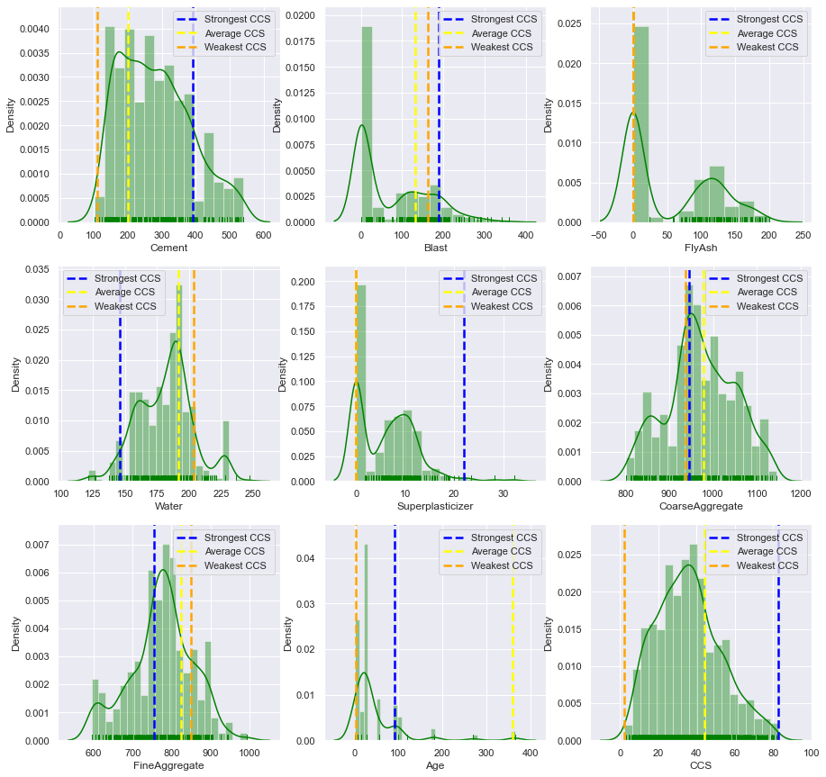

```python
import warnings
warnings.filterwarnings('ignore')
from scipy import stats
import numpy as np
import statistics
import math
from matplotlib import pyplot as plt
import statsmodels.formula.api as smf
import seaborn as sns
sns.set()
fig, axes = plt.subplots(3, 3, figsize= (15,15))
x = 0
for a in range(0, 3):
    for b in range(0, 3):
        col = ConcreteFile.iloc[:,x]
        sns.distplot(col,kde = True,rug=True,ax=axes[a,b], color = 'green')
        axes[a,b].axvline(x=maxL[x],color='blue',ls='--', lw=2.5, label='Strongest CCS')
        axes[a,b].axvline(x=avgL[x],color='yellow',ls='--', lw=2.5, label='Average CCS')
        axes[a,b].axvline(x=minL[x],color='orange',ls='--', lw=2.5, label='Weakest CCS')
        axes[a,b].legend()
        #print('[algo check] row',a,'column',b,'dframe column',x)
        x += 1
plt.show()
```

With these histograms, it can be seen that a lower amount of water will result in a stronger overall compressive strength. More than this, observing the 'Weakest CCS' line in the Cement and Age columns shows us that these both are strongly correlated with the strength of the concrete. Superplasticizer can also be seen to have a strong correlation to strength as seen with the 'Strongest CCS' line. Moreso, it can be seen the FlyAsh has a weak correlation to overall strength.

# Correlation Heatmap with Seaborn

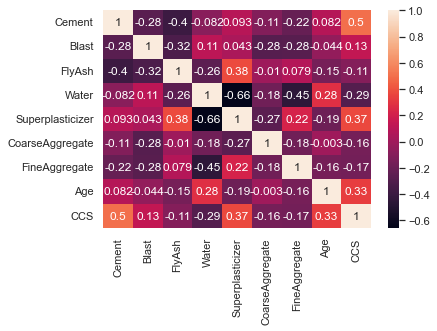

```python
corrMatrix = ConcreteFile.corr()
sns.heatmap(corrMatrix, annot=True)
```

With a correlation heatmap, the relationship to strengths can be further described. As an example, Cement has a 50% correlation to the Compressive strength. Moreso, Superplasticizer and age each have about a 1/3 correlation to strength. This means that the rest of the elements do not drastically positively affect the strength. Water can be seen to have a negative correlation to strength, which also goes with the histogram to prove that a lower amount of water is optimal for overall strength. What is significant to point out as well is the fact that Superplasticizer has a 1/3 correlation with FlyAsh, which has been shown to barely impact the overall compressive strength

# Ordinary Least Squares Regression to visualize relationship to Compressive Strength with Statsmodels

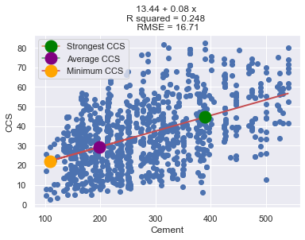

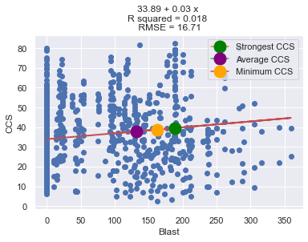

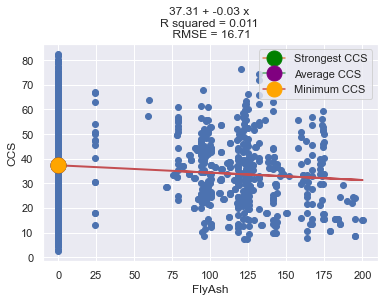

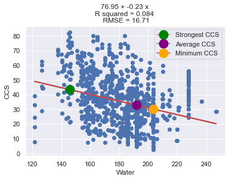

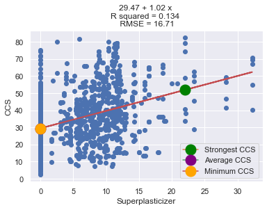

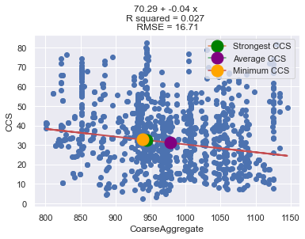

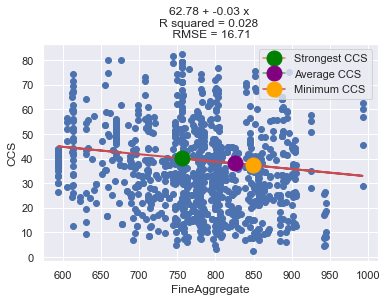

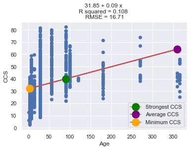

```python
import numpy as np
import pandas as pd
import statistics
import math
from matplotlib import pyplot as plt
import statsmodels.formula.api as smf
columns = list(ConcreteFile)
for x in range(len(columns)):
    if columns[x] != 'CCS':
        model = smf.ols('CCS ~'+ columns[x], data=ConcreteFile)
        model = model.fit()
        intercept = model.params[0]
        slope = model.params[1]
        Rsquare = model.rsquared
        RMSE = math.sqrt(model.mse_total)
        NP_pred = model.predict()
        titleline = str(round(intercept,2)) + ' + ' + str(round(slope,2)) + ' x \n' + 'R squared = ' + str(round(Rsquare,3)) + ' \n RMSE = ' + str(round(RMSE,2))
#         plt.figure(figsize=(10, 6))
        plt.plot(ConcreteFile[columns[x]], ConcreteFile['CCS'], 'o')
        plt.plot()
        pred = []
        for val in ConcreteFile[columns[x]]:
            pred.append(val*round(slope,2) + round(intercept,2))
        plt.plot(ConcreteFile[columns[x]], pred, 'r', linewidth=2)   # regression line
        strongy = []
        meany = []
        miny = []
        for y in range(len(maxL)):
            strongy.append(maxL[y]*round(slope,2) + round(intercept,2))
            meany.append(avgL[y]*round(slope,2) + round(intercept,2))
            miny.append(minL[y]*round(slope,2) + round(intercept,2))
        plt.plot(maxL[x], strongy[x], marker="o", markersize=15, markeredgecolor="green", markerfacecolor="green", label = 'Strongest CCS')
        plt.plot(avgL[x], meany[x], marker="o", markersize=15, markeredgecolor="purple", markerfacecolor="purple", label = 'Average CCS')
        plt.plot(minL[x], miny[x], marker="o", markersize=15, markeredgecolor="orange", markerfacecolor="orange", label = 'Minimum CCS')
        plt.legend()
        plt.xlabel(columns[x])
        plt.ylabel('CCS')
        plt.title(titleline)
        plt.show()
```

```python
y = ConcreteFile['CCS'] # Target variable
X = ConcreteFile.loc[:, ConcreteFile.columns != "CCS"] # all columns except target
from sklearn.model_selection import train_test_split
X_train, X_test, y_train, y_test = train_test_split(X, y, test_size=0.66,random_state=100)
from sklearn.linear_model import LinearRegression
regressor = LinearRegression()
regressor.fit(X_train, y_train) #model trained on 2/3 of data
y_pred=regressor.predict(X_test) #model tested on 1/3 of data
intcpt = regressor.intercept_
coeff = regressor.coef_
pred_df = pd.DataFrame({'Actual': y_test, 'Predicted': y_pred})
pred_df
```

|  | Actual | Predicted |
| --- | --- | --- |
| 173 | 68.099545 | 57.582232 |
| 134 | 71.298713 | 51.766214 |
| 822 | 25.179664 | 23.011942 |
| 264 | 19.519066 | 26.427237 |
| 479 | 38.017707 | 50.312380 |
| ... | ... | ... |
| 890 | 8.535713 | 20.078575 |
| 361 | 55.509713 | 37.754933 |
| 771 | 13.520624 | 22.707643 |
| 748 | 33.212059 | 41.720135 |
| 781 | 14.203206 | 20.034301 |

680 rows × 2 columns

This table visualizes the different between the Actual and the predicted.

```python
from sklearn import metrics
print('Mean Absolute Error:', metrics.mean_absolute_error(y_test, y_pred))
print('Mean Squared Error:', metrics.mean_squared_error(y_test, y_pred))
print('Root Mean Squared Error:', np.sqrt(metrics.mean_squared_error(y_test, y_pred)))
```

```
Mean Absolute Error: 8.286381122094845
Mean Squared Error: 109.45410498037401
Root Mean Squared Error: 10.462031589532408
```

```python
print('Linear Regression model accuracy: ', end  = '')
print(100 - np.sqrt(metrics.mean_squared_error(y_test, y_pred)), '%')
```

```
Linear Regression model accuracy: 89.53796841046758 %
```

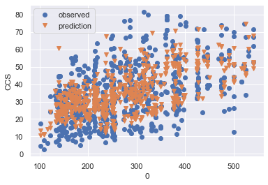

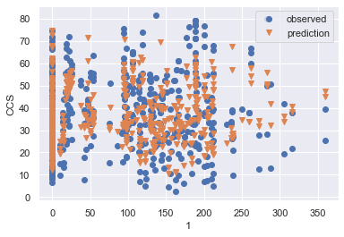

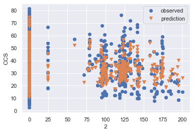

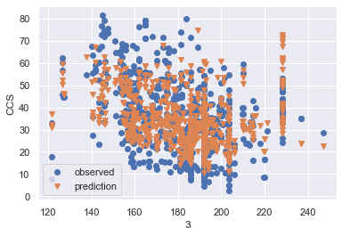

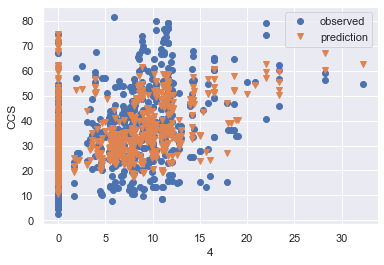

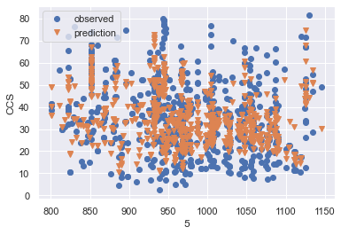

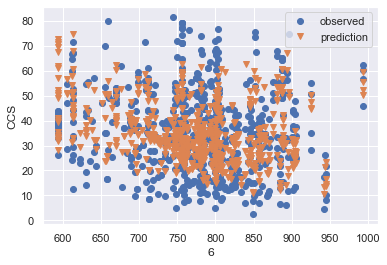

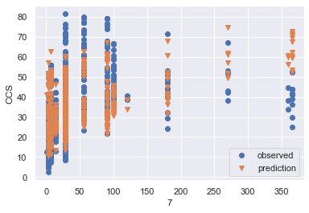

```python
for x in range(len(columns)):
    if columns[x] == 'CCS':
        break
    plt.plot(X_test[columns[x]], y_test, 'o', label = 'observed')
    plt.xlabel(x)
    plt.ylabel('CCS')
    plt.plot(X_test[columns[x]], y_pred, 'v', label = 'prediction')
    plt.legend()
    plt.show()
```

# Data Predicting with User Interface using Linear Regression

```python
import math

def accuracy_score(pred,obs):
    accuracy = 100 - (abs(pred - obs)/obs)*100
    return accuracy

def calculate_CCS():

    Cement = float(input("enter a value for cement: "))
    Blast = float(input("enter a value for Blast Furnace Slag: "))
    FlyAsh = float(input("enter a value for FlyAsh: "))
    Water = float(input("enter a value for Water: "))
    Sup = float(input("enter a value for Superplasticizer: "))
    Coarse = float(input("enter a value for Coarse Aggregate: "))
    Fine = float(input("enter a value for Fine Aggregate: "))
    Age = float(input("enter a value for Age: "))

    ccs = intcpt + Cement*coeff[0] + Blast*coeff[1] + FlyAsh*coeff[2] + Water*coeff[3] + Sup*coeff[4]+ Coarse*coeff[5]+ Fine*coeff[6]+ Age*coeff[7]

    return ccs

def calculate_CCS_exp():

    Cement = float(input("enter a value for cement: "))
    Blast = float(input("enter a value for Blast Furnace Slag: "))
    FlyAsh = float(input("enter a value for FlyAsh: "))
    Water = float(input("enter a value for Water: "))
    Sup = float(input("enter a value for Superplasticizer: "))
    Coarse = float(input("enter a value for Coarse Aggregate: "))
    Fine = float(input("enter a value for Fine Aggregate: "))
    Age = float(input("enter a value for Age: "))

    ccs = intcpt*(Cement**coeff[0]*Blast**coeff[1]*FlyAsh**coeff[2]*Water**coeff[3]*Sup**coeff[4]*Coarse**coeff[5]*Fine**coeff[6]*Age**coeff[7])

    return ccs
```

# i) Linear equation

```python
linModel =  calculate_CCS()
print('Linear formula prediction: ', linModel, 'Compressive strength')
```

```
enter a value for cement: 87
enter a value for Blast Furnace Slag: 9
enter a value for FlyAsh: 8
enter a value for Water: 8
enter a value for Superplasticizer: 99
enter a value for Coarse Aggregate: 99
enter a value for Fine Aggregate: 99
enter a value for Age: 8
Linear formula prediction:  21.836973181334464 Compressive strength
```

# ii) Logarithmic equation

```python
print('Logarithmic formula prediction: ', math.log(linModel), 'Compressive strength')
```

```
Logarithmic formula prediction:  3.083604550673901 Compressive strength
```

# iii) Exponential equation

```python
linModel =  calculate_CCS_exp()
print('Exponential formula prediction: ', linModel, 'Compressive strength')
```

```
enter a value for cement: 8
enter a value for Blast Furnace Slag: 8
enter a value for FlyAsh: 8
enter a value for Water: 8
enter a value for Superplasticizer: 8
enter a value for Coarse Aggregate: 8
enter a value for Fine Aggregate: 8
enter a value for Age: 8
Exponential formula prediction:  -71.84348669083377 Compressive strength
```

We can briefly examine the accuracy of these models by comparing them to the combination for the strongest compressive strength

```python
maxL
```

```
[389.9, 189.0, 0.0, 145.9, 22.0, 944.7, 755.8, 91.0, 82.5992248]
```

```python
Cement = 389.9
Blast = 189
FlyAsh = 0.01
Water = 145.9
Sup = 22
Coarse = 944.7
Fine = 755.8
Age = 91.0
ccs = intcpt + Cement*coeff[0] + Blast*coeff[1] + FlyAsh*coeff[2] + Water*coeff[3] + Sup*coeff[4]+ Coarse*coeff[5]+ Fine*coeff[6]+ Age*coeff[7]
ccs_exp = intcpt*(Cement**coeff[0]*Blast**coeff[1]*FlyAsh**coeff[2]*Water**coeff[3]*Sup**coeff[4]*Coarse**coeff[5]*Fine**coeff[6]*Age**coeff[7])

print('Linear Model: ',accuracy_score(ccs, maxL[8]),'% accurate')
print('Logarithmic Model: ',accuracy_score(math.log(ccs), maxL[8]),'% accurate')
print('Exponential Model: ',accuracy_score(ccs_exp, maxL[8]),'% accurate')
```

```
Linear Model:  80.75125437872403 % accurate
Logarithmic Model:  5.085039981623254 % accurate
Exponential Model:  -152.34479800031332 % accurate
```

As seen, the Linear equation provides the most accuracy

# Decision Tree Predictions

```python
from sklearn.tree import DecisionTreeRegressor
regressor = DecisionTreeRegressor(random_state = 0)
regressor.fit(X_train, y_train)
```

```
DecisionTreeRegressor(random_state=0)
```

We can estimate the accuracy of the Decision Tree

```python
y_pred_tree = regressor.predict(X_test)
print('Mean Absolute Error:', metrics.mean_absolute_error(y_test, y_pred_tree))
print('Mean Squared Error:', metrics.mean_squared_error(y_test, y_pred_tree))
print('Root Mean Squared Error:', np.sqrt(metrics.mean_squared_error(y_test, y_pred_tree)))
print('Accuracy of Decision tree', 100 - np.sqrt(metrics.mean_squared_error(y_test, y_pred_tree)))
```

```
Mean Absolute Error: 6.208657507584465
Mean Squared Error: 88.85316332538076
Root Mean Squared Error: 9.426195591296668
Accuracy of Decision tree 90.57380440870332
```

# Random Forest Predictions

```python
from sklearn.ensemble import RandomForestRegressor
from sklearn.datasets import make_regression
regr_obj = RandomForestRegressor(max_depth=3, random_state=0)
regr_obj.fit(X_train, y_train)
pred_randfor = regr_obj.predict(X_test)
```

```python
print('Mean Absolute Error:', metrics.mean_absolute_error(y_test, pred_randfor))
print('Mean Squared Error:', metrics.mean_squared_error(y_test, pred_randfor))
print('Root Mean Squared Error:', np.sqrt(metrics.mean_squared_error(y_test, pred_randfor)))
print('Accuracy of Decision tree', 100 - np.sqrt(metrics.mean_squared_error(y_test, y_pred_tree)))
```

```
Mean Absolute Error: 8.201150589569478
Mean Squared Error: 110.3774941347858
Root Mean Squared Error: 10.506069395106136
Accuracy of Decision tree 90.57380440870332
```

As seen, the Decision Tree produces the least amount of errors overall. We will use this model to test 5 different combinations

# Using Decision Trees to predict combinations

```python
sample1 = [[175.0,13.0,172.0,1000.0,856.0,156.0,4.0,3.0]]
sample2 = [[320.0,0.0,0.0,970.0,850.0,192.0,0.0,7.0]]
sample3 = [[320.0,0.0,126.0,860.0,856.0,209.0,5.70,28.0]]
sample4 = [[320.0,73.0,54.0,972.0,773.0,181.0,6.0,45.0]]
sample5 = [[530.0,359.0,200.0,1145.0,992.0,247.0,32.0,365.0]]
```

```python
print('Prediction for sample 1:', float(regressor.predict(sample1)),'KPa')
print('Prediction for sample 2:', float(regressor.predict(sample2)),'KPa')
print('Prediction for sample 3:', float(regressor.predict(sample3)),'KPa')
print('Prediction for sample 4:', float(regressor.predict(sample4)),'KPa')
print('Prediction for sample 5:', float(regressor.predict(sample5)),'KPa')
```

```
Prediction for sample 1: 28.79941252 KPa
Prediction for sample 2: 42.79577532 KPa
Prediction for sample 3: 31.875164956000003 KPa
Prediction for sample 4: 33.116911232 KPa
Prediction for sample 5: 73.29819356 KPa
```

# Adding Observations to the DataBase

using Decision Tree to predict compressive strength

```python
Add_obs = ConcreteFile
```

```python
Cement = float(input("enter a value for cement: "))
Blast = float(input("enter a value for Blast Furnace Slag: "))
FlyAsh = float(input("enter a value for FlyAsh: "))
Water = float(input("enter a value for Water: "))
Sup = float(input("enter a value for Superplasticizer: "))
Coarse = float(input("enter a value for Coarse Aggregate: "))
Fine = float(input("enter a value for Fine Aggregate: "))
Age = float(input("enter a value for Age: "))
learn = [Cement, Blast, FlyAsh, Water, Sup, Coarse, Fine, Age]
y_pred_tree = regressor.predict([learn])
learn.append(float(y_pred_tree))
print('Prediction: ',float(y_pred_tree))
Add_obs.loc[len(Add_obs.index)] = learn
Add_obs.tail()
```

```
enter a value for cement: 1
enter a value for Blast Furnace Slag: 2
enter a value for FlyAsh: 3
enter a value for Water: 4
enter a value for Superplasticizer: 5
enter a value for Coarse Aggregate: 6
enter a value for Fine Aggregate: 78
enter a value for Age: 8
Prediction:  42.79577532
```

|  | Cement | Blast | FlyAsh | Water | Superplasticizer | CoarseAggregate | FineAggregate | Age | CCS |
| --- | --- | --- | --- | --- | --- | --- | --- | --- | --- |
| 1026 | 322.2 | 0.0 | 115.6 | 196.0 | 10.4 | 817.9 | 813.4 | 28.0 | 31.178794 |
| 1027 | 148.5 | 139.4 | 108.6 | 192.7 | 6.1 | 892.4 | 780.0 | 28.0 | 23.696601 |
| 1028 | 159.1 | 186.7 | 0.0 | 175.6 | 11.3 | 989.6 | 788.9 | 28.0 | 32.768036 |
| 1029 | 260.9 | 100.5 | 78.3 | 200.6 | 8.6 | 864.5 | 761.5 | 28.0 | 32.401235 |
| 1030 | 1.0 | 2.0 | 3.0 | 4.0 | 5.0 | 6.0 | 78.0 | 8.0 | 42.795775 |

# References:

- Lab 30, 31, 32, 18_TH

-Using Sci_kit Learn

- https://scikit-learn.org/stable/index.html

-Using Seaborn

- https://datavizpyr.com/how-to-add-a-mean-median-line-to-a-seaborn-displot/
- https://seaborn.pydata.org/generated/seaborn.heatmap.html

-Decision Trees and Random Forests

- https://www.geeksforgeeks.org/python-decision-tree-regression-using-sklearn/
- https://scikit-learn.org/stable/modules/generated/sklearn.ensemble.RandomForestRegressor.html

-Linear Regression in sklearn

- https://datagy.io/python-sklearn-linear-regression/

-Using Matplotlib

- https://www.w3schools.com/python/matplotlib_histograms.asp